# Introduction and Principles

Mark Dunning

Last modified: 05 Dec 2016

# Why is this course important?

[figure not shown]

Copyright by Sidney Harris

# Reproducible Research

- As modern researchers, we should care about *reproducible research*.
- At some point in the future, someone, somewhere, might want to repeat your analysis for themselves or re-use your data.
  - which will most likely be *you!*
- Assuming that you’ll be able to remember all the steps involved is dangerous, so making sure that everything is well-documented is key.
- The documentation involves not only the methods used, but the files used as input and any transformations performed on them.

# Five selfish reasons

- Florian Markowetz has a great talk on why we should work reproducibly
- There is a [Genome Biology paper](http://genomebiology.biomedcentral.com/articles/10.1186/s13059-015-0850-7) that you should read.

[figure not shown]

# A famous example

- Probably the most (in)famous example of failure to reproduce a study, which actually *put people’s lives at risk* and [rallied statisticians into action](http://www.nytimes.com/2011/07/08/health/research/08genes.html)
- Keith Baggerly’s lecture on the scandal is a *must-see*.

[video not shown]

# But tools like R have been around for years; why is this still an issue?

- R is only part of the solution
- Say you use an R script to generate a list of interesting genes and come to publish
  - which set of samples was used….the one with that dodgy sample removed
  - didn’t you change the version of the software and re-run it?
  - what filters did you apply afterwards
- Need complete control over the files and data associated with your project

# Key concepts

The key areas that we will address in this course are:-

1. Making sure the analysis can be automated
2. Knowing exactly what files were used as input and output
3. Making your data available to others

# Barriers to learning R, Python etc

- Hopefully you will take the opportunity to learn a course to learn a language such as [R](http://cambiotraining.github.io/r-intro/) or [Python](http://pycam.github.io/) for your data analysis.
- From experience, the biggest hurdle that newcomers to these languages face itrying to read and analyse your own data
- Often not because you have not understood the course materials….
- ….but because the data have been managled into a form that the computer cannot process.
- there’s a danger of becoming de-motivated and resorting back to whatever software you were using before.

# Are spreadsheets programs like Excel evil?

- ….Not neccesarily.
- Often much more convenient to eye-ball a spreadsheet and get an overall impression of your data.
- But they have *limitations* making them not ideal for large-scale analyses.
- Doing things by-hand only invites you to make copy-and-paste errors etc

# Bottom-line

- Your carefully-crafted, colourful, all-singing, all-dancing, multi-tab spreadsheet probably won’t read very easily into R.
- Computers are very literal **don’t make any assumptions about the data**. They won’t be able to tell the difference between the text entries `MALE` and `male`, `Male`.
- Nor can they discern colours or other types of formatting in the data.
- Bioinformaticians are very-skilled in the art of ‘data munging’ or ‘data wrangling’
  - and all the errors in files that we will discuss have a solution in software such as R.
- But would you rather they spend their time analysing the data, or manipulating it?
- Check with them what format they would like the data in
  - and stick to it!
  - often it will be raw-data untouched by humans

# Meta-data

- At some points in the analysis process spreadsheets are *unavoidable*.
- The *metadata* for the experiment is the description of what biological group each sample belongs to and other useful information such as the conditions under which each sample was derived
- (e.g. batch, cage) and other characteristics of confounding factors (e.g. sex, age) that might influence the analysis.
- They are often immortalised with a publication for everyone to see

[figure not shown]

# What about other people’s metadata?

- Even if we take great care of our own metadata, others who make their data available or collaborate might not be so careful.
- We will introduce [Open Refine](http://openrefine.org/), *a free open source, powerful tool for working with messy data* that can help to transform data.

[figure not shown]

# When do we have to worry about such things?

- *From the very beginning!*
- Creating documentation for our data and keeping things tidy may seem tedious
- ….trying to pull everything together for a paper submission is an *extremely painful* process.
- often cited as a reason for people not sharing their data
- you may have no choice about sharing your data
- better to get things in shape from the start

# Plan for the workshop

- Data formatting issues
  - how can we make sure our files are readable by computers
  - what mistakes to avoid
- Open Refine demo
  - how we can clean-up files
- How to manage the files in a project
- How to keep a backup
- How (and why) to share with others
  - and what resources are available

# Some general principles and themes

# Principle 1

1. **Make sure your files are amenable for analysis**

[figure not shown]

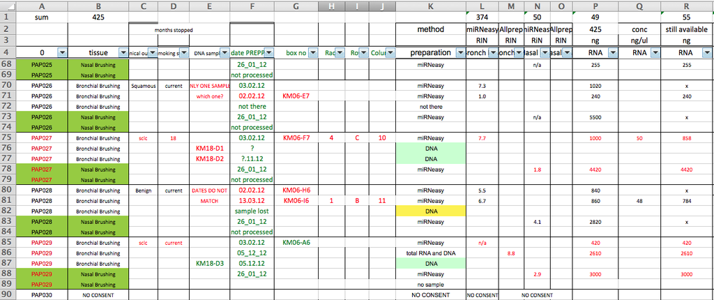

We will discuss this point in more detail in the next section.

# Principle 2

2. **Never work directly on the raw data**

[figure not shown]

http://www.inquisitr.com/309687/jesus-painting-restoration-goes-wrong-well-intentioned-old-lady-destroys-100-year-old-fresco/

# Principle 3

3. **Ensure you have a secure backup strategy**

Should be self-explanatory!

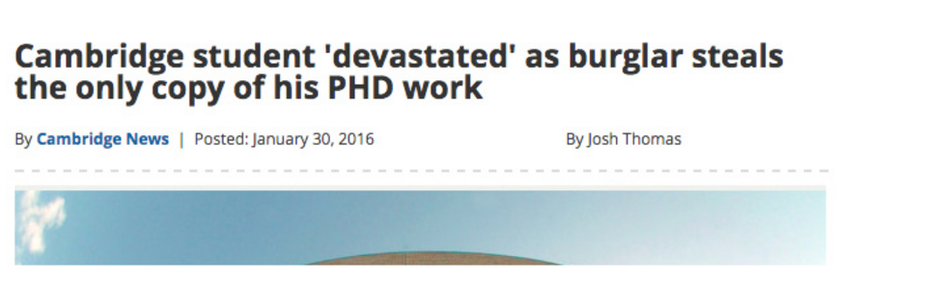

Cambridge News; Jan 30th 2016

# Principle 4

4. **Embrace version control**

# Principle 5

5. Organise your files / directories

[figure not shown]

# Principle 6

6. Make yourself visible

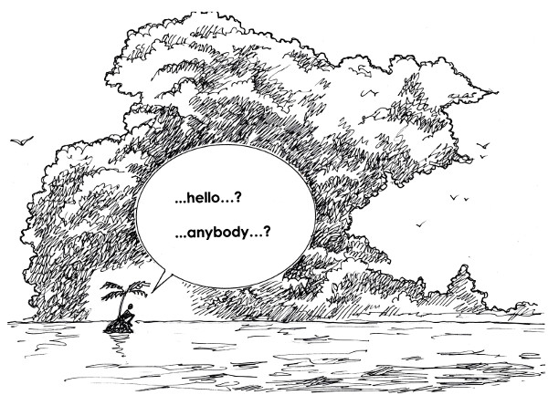

whyopenresearch.org/

Erin and John McKiernan

# References

- [Data carpentry workshops](http://lgatto.github.io/2016-05-16-CAM/)
- [The Quartz guide to bad data](https://github.com/Quartz/bad-data-guide/blob/master/README.md)
- [Three common bad practices in sharing tables and spreadsheets and how to avoid them.](http://luisdva.github.io/pls-don't-do-this/)
- [The Data Organisation tutorial by Karl Broman](http://kbroman.org/dataorg/)
- [Biologists: this is why bioinformaticians hate you…](http://www.opiniomics.org/biologists-this-is-why-bioinformaticians-hate-you/)
- [WhyOpenResearch.org](http://whyopenresearch.org/)